# Plot Lottery

Leo Lu

2016-09-24

(Inherited the work by [George Chao](https://github.com/whizzalan))

本範例需要的套件

```r
library(magrittr)
library(readr)
library(data.table)
library(dplyr)
library(dtplyr)
library(ggplot2)
library(tidyr)
library(lubridate)
```

## Data

### Download the Data

```r
dir.create("data", showWarnings = FALSE, recursive = TRUE)
download.file("https://raw.githubusercontent.com/datasci-info/JihSunRBasic20160724/gh-pages/3_RViz_201608/data/lottery_utf8.csv?token=AIV30aRvlYfgHvWfe60M34FbUEtURVoUks5XxZ3qwA%3D%3D", destfile = "data/lottery_utf8.csv")
```

### Data Cleansing

```r
lottery_raw <- read_csv("data/lottery_utf8.csv",
                    locale = locale(encoding = "UTF-8"),
                    col_types = cols(.default = "c")) %>%
  select(-c(3,29:33)) %>%  # exclude `兌獎截止`
  tbl_dt
raw_names <- names(lottery_raw)
lottery <- lottery_raw %>%
  setNames(c("period", "date", "sales", "total_rewards",
             paste0("n",1:6), "s",
             sprintf("n_%s_prize", 1:8),
             sprintf("money_%s_prize", 1:8))) %>%
  separate(date, into = c("year", "mm", "dd")) %>%
  mutate(year = as.integer(year)+1911) %>%
  unite(date, year, mm, dd, sep="-", remove=TRUE) %>%
  mutate(date = as.Date(date))
int_cols <- names(lottery) %>% grep("^n_", ., value =  TRUE)
num_cols <- names(lottery) %>% grep("^money|rewards|sales", ., value =  TRUE)
lottery[, (int_cols) := lapply(.SD, as.integer), .SDcols = int_cols][
  , (num_cols) := lapply(.SD, as.numeric), .SDcols = num_cols]
```

```
#> Source: local data table [287 x 27]
#>
#> # tbl_dt [287 × 27]
#>       period       date     sales total_rewards    n1    n2    n3    n4
#> *      <chr>     <date>     <dbl>         <dbl> <chr> <chr> <chr> <chr>
#> 1  105000070 2016-08-09  79682500      43825375    15    37    35    17
#> 2  105000069 2016-08-05 106107950     306863197    27    40    02    35
#> 3  105000068 2016-08-02 100001650     284598110    15    04    20    22
#> 4  105000067 2016-07-29  98424000     260310379    28    09    27    15
#> 5  105000066 2016-07-26  95455250     239899326    35    41    19    22
#> 6  105000065 2016-07-22  92361650     216141278    17    10    33    02
#> 7  105000064 2016-07-19  88800350     193957335    07    46    40    33
#> 8  105000063 2016-07-15  89791000     175442258    29    24    25    35
#> 9  105000062 2016-07-12  84696350     151879481    42    31    46    43
#> 10 105000061 2016-07-08  69608650     132848889    13    10    09    19
#> # ... with 277 more rows, and 19 more variables: n5 <chr>, n6 <chr>,
#> #   s <chr>, n_1_prize <int>, n_2_prize <int>, n_3_prize <int>,
#> #   n_4_prize <int>, n_5_prize <int>, n_6_prize <int>, n_7_prize <int>,
#> #   n_8_prize <int>, money_1_prize <dbl>, money_2_prize <dbl>,
#> #   money_3_prize <dbl>, money_4_prize <dbl>, money_5_prize <dbl>,
#> #   money_6_prize <dbl>, money_7_prize <dbl>, money_8_prize <dbl>
```

```r
lottery <- lottery %>% tbl_df
```

| variables | detail |
| --- | --- |
| period | 期別 |
| date | 開獎日 |
| sales | 銷售金額 |
| total_rewards | 獎金總額 |
| n1 | 獎號_1 |
| n2 | 獎號_2 |
| n3 | 獎號_3 |
| n4 | 獎號_4 |
| n5 | 獎號_5 |
| n6 | 獎號_6 |
| s | 特別號 |
| n_1_prize | 頭獎_中獎注數 |
| n_2_prize | 貳獎_中獎注數 |
| n_3_prize | 參獎_中獎注數 |
| n_4_prize | 肆獎_中獎注數 |
| n_5_prize | 伍獎_中獎注數 |
| n_6_prize | 陸獎_中獎注數 |
| n_7_prize | 柒獎_中獎注數 |
| n_8_prize | 普獎_中獎注數 |
| money_1_prize | 頭獎_單注獎金 |
| money_2_prize | 貳獎_單注獎金 |
| money_3_prize | 參獎_單注獎金 |
| money_4_prize | 肆獎_單注獎金 |
| money_5_prize | 伍獎_單注獎金 |
| money_6_prize | 陸獎_單注獎金 |
| money_7_prize | 柒獎_單注獎金 |
| money_8_prize | 普獎_單注獎金 |

|  | period | date | sales | total_rewards | n1 | n2 | n3 | n4 | n5 | n6 | s | n_1_prize | n_2_prize | n_3_prize | n_4_prize | n_5_prize | n_6_prize | n_7_prize | n_8_prize | money_1_prize | money_2_prize | money_3_prize | money_4_prize | money_5_prize | money_6_prize | money_7_prize | money_8_prize |
| --- | --- | --- | --- | --- | --- | --- | --- | --- | --- | --- | --- | --- | --- | --- | --- | --- | --- | --- | --- | --- | --- | --- | --- | --- | --- | --- | --- |
| 1 | 105000070 | 2016-08-09 | 79682500 | 43825375 | 15 | 37 | 35 | 17 | 45 | 30 | 41 | 0 | 0 | 36 | 76 | 1355 | 1770 | 18205 | 23493 | 0 | 0 | 42293 | 13355 | 2060 | 1000 | 400 | 400 |
| 2 | 105000069 | 2016-08-05 | 106107950 | 306863197 | 27 | 40 | 02 | 35 | 22 | 01 | 33 | 1 | 1 | 32 | 84 | 1818 | 2605 | 26380 | 33497 | 271720432 | 1908214 | 59631 | 15144 | 1924 | 1000 | 400 | 400 |
| 3 | 105000068 | 2016-08-02 | 100001650 | 284598110 | 15 | 04 | 20 | 22 | 28 | 29 | 01 | 0 | 2 | 38 | 126 | 1831 | 2834 | 26918 | 32659 | 0 | 1739451 | 44741 | 8995 | 1702 | 1000 | 400 | 400 |
| 4 | 105000067 | 2016-07-29 | 98424000 | 260310379 | 28 | 09 | 27 | 15 | 30 | 41 | 13 | 0 | 0 | 27 | 95 | 1691 | 2272 | 23964 | 31575 | 0 | 0 | 65879 | 12482 | 1928 | 1000 | 400 | 400 |
| 5 | 105000066 | 2016-07-26 | 95455250 | 239899326 | 35 | 41 | 19 | 22 | 09 | 15 | 37 | 0 | 1 | 27 | 88 | 1633 | 2434 | 23987 | 31133 | 0 | 3356285 | 62263 | 12735 | 1887 | 1000 | 400 | 400 |
| 6 | 105000065 | 2016-07-22 | 92361650 | 216141278 | 17 | 10 | 33 | 02 | 49 | 27 | 15 | 0 | 0 | 28 | 95 | 1562 | 2184 | 22809 | 28929 | 0 | 0 | 59827 | 11755 | 1966 | 1000 | 400 | 400 |
| 7 | 105000064 | 2016-07-19 | 88800350 | 193957335 | 07 | 46 | 40 | 33 | 45 | 13 | 39 | 0 | 1 | 32 | 94 | 1391 | 2280 | 22245 | 24891 | 0 | 1662347 | 51948 | 11789 | 2190 | 1000 | 400 | 400 |
| 8 | 105000063 | 2016-07-15 | 89791000 | 175442258 | 29 | 24 | 25 | 35 | 33 | 38 | 49 | 0 | 1 | 23 | 63 | 1573 | 1960 | 19381 | 28508 | 0 | 3272930 | 73746 | 17948 | 1976 | 1000 | 400 | 400 |
| 9 | 105000062 | 2016-07-12 | 84696350 | 151879481 | 42 | 31 | 46 | 43 | 25 | 34 | 05 | 0 | 0 | 12 | 50 | 1288 | 1962 | 21283 | 24571 | 0 | 0 | 131396 | 21023 | 2244 | 1000 | 400 | 400 |
| 10 | 105000061 | 2016-07-08 | 69608650 | 132848889 | 13 | 10 | 09 | 19 | 35 | 23 | 38 | 0 | 1 | 25 | 81 | 1556 | 1810 | 18136 | 26093 | 0 | 4106336 | 45079 | 9275 | 1327 | 1000 | 400 | 400 |

[output cut: 277 more lines]

## EDA

### 每期頭獎人數分布

- Issue: 我想知道頭獎最多幾個人分走惹？沒開出頭獎的期數多嗎？
- Variables
  - n_1_prize
- Geoms
  - maybe `bar chart`. Since it’s a ordered variable.
- Mapping
  - x: n_1_prize
  - y: count **期數** (n rows) by n_1_prize

```r
d <- lottery %>%
  group_by(n_1_prize) %>%
  summarise(n = n())
d
```

```
#> # A tibble: 4 × 2
#>   n_1_prize     n
#>       <int> <int>
#> 1         0   228
#> 2         1    47
#> 3         2    10
#> 4         3     2
```

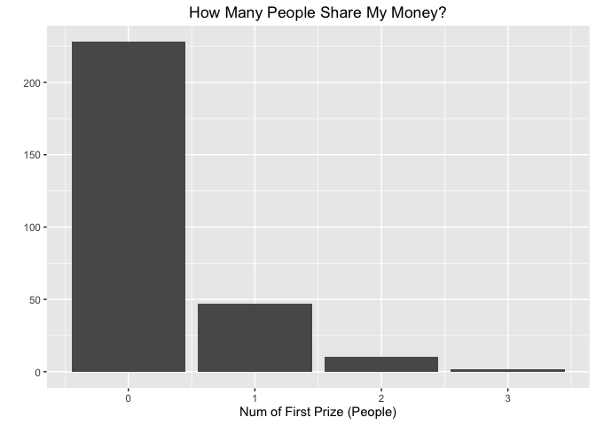

```r
ggplot(d, aes(n_1_prize, n)) +
  geom_bar(stat = "identity") +
  ggtitle("How Many People Share My Money?") +
  xlab("Num of First Prize (People)") +
  ylab("")
```

### 月份銷售總額

- Issue: 今天如果你是中信員工，老闆想了解大樂透總體營運情況，看大樂透月份銷售總額？
- Variables
  - date
  - sales
- Geoms
  - maybe `bar chart` or `line chart`? Since it’s a continuous variable.
- Mapping
  - x: date
  - y: sum sales by month

```r
d <- lottery %>%
  mutate(month = floor_date(date, "month")) %>%
  group_by(month) %>%
  summarise(total_sales_M = sum(sales/1000000))
d
```

```
#> # A tibble: 32 × 2
#>         month total_sales_M
#>        <date>         <dbl>
#> 1  2014-01-01     2402.2791
#> 2  2014-02-01     2828.2831
#> 3  2014-03-01      908.7441
#> 4  2014-04-01      934.0008
#> 5  2014-05-01     1013.8432
#> 6  2014-06-01      818.9230
#> 7  2014-07-01     1082.7311
#> 8  2014-08-01      884.9505
#> 9  2014-09-01      980.7276
#> 10 2014-10-01      919.0896
#> # ... with 22 more rows
```

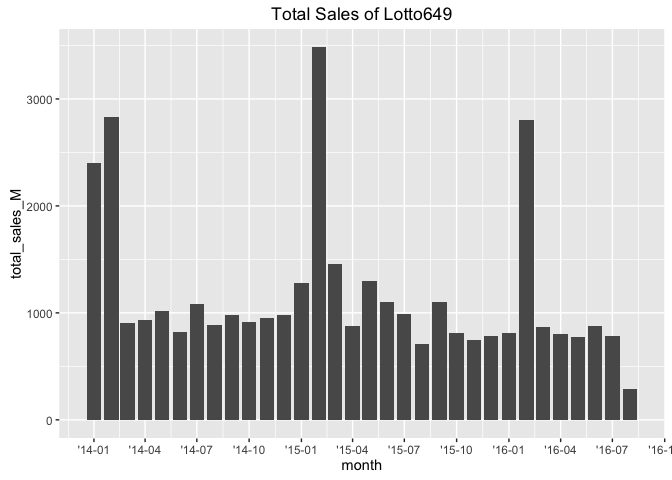

```r
ggplot(d, aes(x = month, total_sales_M)) +
  geom_bar(stat = "identity") +
  scale_x_date(date_breaks = "3 month", date_labels = "'%y-%m") +
  ggtitle("Total Sales of Lotto649")
```

### 總獎金

- Issue: 想知道大樂透的歷史買氣如何？現在算多人買嗎？
- Variables
  - total_rewards
  - date
- Geoms
  - maybe `bar chart` or `line chart`? Since it’s a continuous variable.
- Mapping
  - x: date
  - y: total_rewards

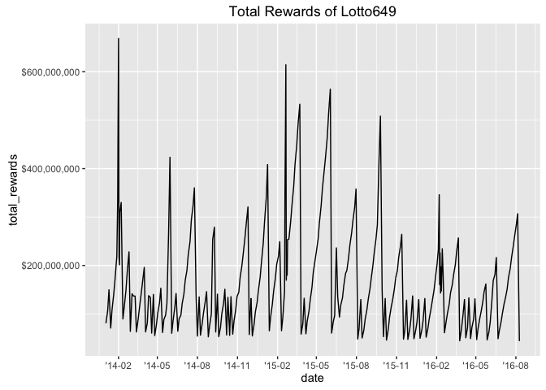

```r
ggplot(lottery, aes(x = date, y = total_rewards)) +
  geom_line(stat = "identity") +
  scale_x_date(date_breaks = "3 month", date_labels = "'%y-%m") +
  scale_y_continuous(labels = scales::dollar) +
  ggtitle("Total Rewards of Lotto649")
```

### 每個月總獎金與頭獎獎金

- Issue: 每個月總獎金熱度為何？頭獎有多幸運呢？
- Variables
  - total_rewards
  - money_1_prize
  - date -> month
- Geoms
  - maybe `dot chart`, `line chart`
- Mapping
  - x: month (calculated from date)
  - y: sum total_rewards by month
  - y: dollars
  - facet: variables(sum money_1_prize, sum total_rewards by month)

```r
d <- lottery %>%
  mutate(month = floor_date(date, "month")) %>%
  group_by(month) %>%
  summarise(sum_total_rewards_M = sum(total_rewards)/1000000,
            sum_money_1_prize_M = sum(money_1_prize)/1000000) %>%
  gather(variables, dollars_million, -month)
d
```

```
#> # A tibble: 64 × 3
#>         month           variables dollars_million
#>        <date>               <chr>           <dbl>
#> 1  2014-01-01 sum_total_rewards_M       1894.4509
#> 2  2014-02-01 sum_total_rewards_M       2558.8559
#> 3  2014-03-01 sum_total_rewards_M        987.4597
#> 4  2014-04-01 sum_total_rewards_M        945.8526
#> 5  2014-05-01 sum_total_rewards_M       1442.3084
#> 6  2014-06-01 sum_total_rewards_M        772.1097
#> 7  2014-07-01 sum_total_rewards_M       2085.5668
#> 8  2014-08-01 sum_total_rewards_M        828.1659
#> 9  2014-09-01 sum_total_rewards_M       1183.1197
#> 10 2014-10-01 sum_total_rewards_M        921.5685
#> # ... with 54 more rows
```

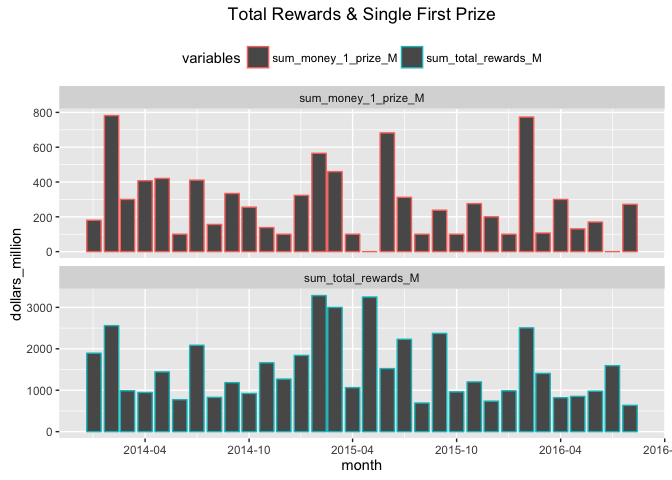

```r
ggplot(d, aes(x = month, y = dollars_million, color = variables)) +
  geom_bar(stat = "identity") +
  facet_wrap( ~ variables, ncol = 1, scales = "free_y") +
  scale_x_date(date_breaks = "6 month", date_labels = "%Y-%m") +
  theme(legend.position = "top") +
  ggtitle("Total Rewards & Single First Prize")
```

### 每期總獎金與頭獎人數

- Issue: 每期總獎金高頭獎就分得多嗎？有多少人跟我分頭獎？
- Variables
  - total_rewards
  - money_1_prize
  - date -> month
- Geoms
  - maybe `dot chart` with color hue
- Mapping
  - x: total rewards
  - y: money_1_prizes
  - y: sum money_1_prize by month

```r
d <- lottery %>%
  select(total_rewards, money_1_prize, n_1_prize) %>%
  mutate_at(vars(total_rewards, money_1_prize), funs(M = ./1000000))
d
```

```
#> # A tibble: 287 × 5
#>    total_rewards money_1_prize n_1_prize total_rewards_M money_1_prize_M
#>            <dbl>         <dbl>     <int>           <dbl>           <dbl>
#> 1       43825375             0         0        43.82538          0.0000
#> 2      306863197     271720432         1       306.86320        271.7204
#> 3      284598110             0         0       284.59811          0.0000
#> 4      260310379             0         0       260.31038          0.0000
#> 5      239899326             0         0       239.89933          0.0000
#> 6      216141278             0         0       216.14128          0.0000
#> 7      193957335             0         0       193.95734          0.0000
#> 8      175442258             0         0       175.44226          0.0000
#> 9      151879481             0         0       151.87948          0.0000
#> 10     132848889             0         0       132.84889          0.0000
#> # ... with 277 more rows
```

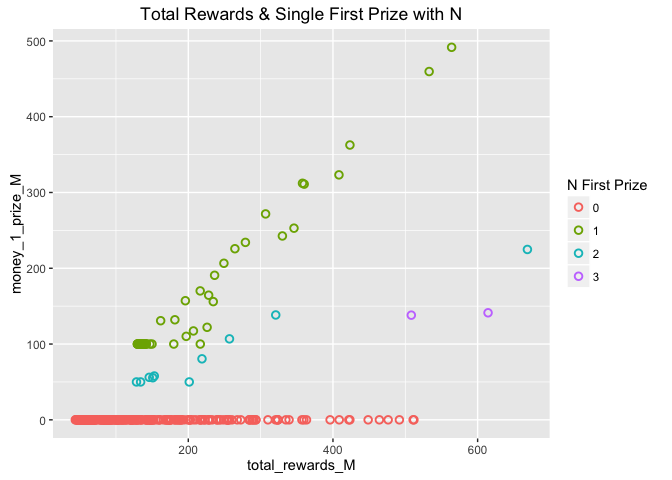

```r
ggplot(d, aes(x = total_rewards_M, y = money_1_prize_M, color = factor(n_1_prize))) +
  geom_point(shape = 1, size = 2, stroke = 1) +
  scale_color_discrete(name = "N First Prize") +
  ggtitle("Total Rewards & Single First Prize with N")
```

### 號碼的「冷度」

- Issue: 有哪些號碼是很久沒開了？幾期沒開了？「冷度」如何？
- Variables
  - period
  - numbers
  - 累計沒開期數
- Geoms
  - maybe `heatmap` with color hue
- Mapping
  - x: period
  - y: numbers
  - color hue: 累計沒開期數

```r
library(dplyr)
library(RColorBrewer)
rle_seq <- function(x) {
  # x <- c(0, 0, 1, 1, 0, 0, 0, 1, 1, 1, 0, 0)
  rle_df <- rle(x) %>% unclass() %>% as.data.frame()

  # lengths <- rle_list$lengths
  # values <- rle_list$values
  #
  # zero_pos <- which(values == 0)
  # one_pos <- which(values == 1)
  #
  # n_zeros <- lengths[zero_pos]
  # n_ones <- lengths[one_pos]
  #
  # seq(zeros[1], 1, -1)
  # seq(zeros[2], 1, -1)
  # seq(zeros[3], 1, -1)
  #
  # rep(0, ones[1])
  # rep(0, ones[2])
  #
  # expected_result <- c(2, 1, 0, 0, 3, 2, 1, 0, 0, 0, 2, 1)

  rle_df <- rle_df %>%
    rowwise() %>%
    mutate(rle_seq = ifelse(values == 0, list(seq(lengths, 1, -1)),
                            list(rep(0, lengths))))
  rle_df$rle_seq %>% unlist(use.names = FALSE)
}

# 展開成每個號碼
lottery_m <- lottery %>%
  select(1,n1:s) %>%
  gather(key = var, value = val, n1:s) %>%
  select(-var) %>%
  mutate(YesNo = 1) %>%
  spread(key = val, value = YesNo, fill=0) %>%
  arrange(desc(period))
lottery_m
```

```
#> # A tibble: 287 × 50
#>       period  `01`  `02`  `03`  `04`  `05`  `06`  `07`  `08`  `09`  `10`
#>        <chr> <dbl> <dbl> <dbl> <dbl> <dbl> <dbl> <dbl> <dbl> <dbl> <dbl>
#> 1  105000070     0     0     0     0     0     0     0     0     0     0
#> 2  105000069     1     1     0     0     0     0     0     0     0     0
#> 3  105000068     1     0     0     1     0     0     0     0     0     0
#> 4  105000067     0     0     0     0     0     0     0     0     1     0
#> 5  105000066     0     0     0     0     0     0     0     0     1     0
#> 6  105000065     0     1     0     0     0     0     0     0     0     1
#> 7  105000064     0     0     0     0     0     0     1     0     0     0
#> 8  105000063     0     0     0     0     0     0     0     0     0     0
#> 9  105000062     0     0     0     0     1     0     0     0     0     0
#> 10 105000061     0     0     0     0     0     0     0     0     1     1
#> # ... with 277 more rows, and 39 more variables: `11` <dbl>, `12` <dbl>,
#> #   `13` <dbl>, `14` <dbl>, `15` <dbl>, `16` <dbl>, `17` <dbl>,
#> #   `18` <dbl>, `19` <dbl>, `20` <dbl>, `21` <dbl>, `22` <dbl>,
#> #   `23` <dbl>, `24` <dbl>, `25` <dbl>, `26` <dbl>, `27` <dbl>,
#> #   `28` <dbl>, `29` <dbl>, `30` <dbl>, `31` <dbl>, `32` <dbl>,
#> #   `33` <dbl>, `34` <dbl>, `35` <dbl>, `36` <dbl>, `37` <dbl>,
#> #   `38` <dbl>, `39` <dbl>, `40` <dbl>, `41` <dbl>, `42` <dbl>,
#> #   `43` <dbl>, `44` <dbl>, `45` <dbl>, `46` <dbl>, `47` <dbl>,
#> #   `48` <dbl>, `49` <dbl>
```

```r
# 距離多久沒開出來
# rle_seq(lottery_m$`01`)
d <- lottery_m %>%
  filter(period >= "105000001") %>%  # 只篩選今年的資料
  mutate_at(vars(-contains("period")), rle_seq) %>%  # 針對號碼變數計算多久沒開
  gather(key = number, value = rle, -period)


# 畫圖 ---------------------------------------------

# 先算好每 10 期一個刻度
breaks <- seq(d$period %>% as.integer() %>% min,
              d$period %>% as.integer() %>% max,
              10)

ggplot(d, aes(x = factor(period),
              y = factor(number, rev(levels(factor(number)))),
              fill = rle)) +
  geom_tile(colour="white", size = 0.5) +
  scale_fill_gradientn(name = "Non-open Periods", colours = brewer.pal(5, "YlGnBu"), guide = "legend") +  # 調整數值變數的顏色
  geom_tile(data = d %>% filter(rle == 0),
            fill = "grey", colour = "white", size = 0.5) + # 開出的號碼
  scale_x_discrete(breaks = breaks) +
  theme(legend.position="top") +
  ylab("Numbers") +
  xlab("Period") +
  ggtitle("Lottery 49/6 Coolness")
```

[figure not shown]